# Association Rules

#### Association Rules: Notes from *Data Science and Big Data Analytics* from Wiley.

*Confidence* is defined as the measure of the certainty or trustworthiness associated with each discovered rule. Confidence is the percent of transactions that contain both $X$ and $Y$ out of all the transactions that contain $X$.

$$Confidence(X\rightarrow Y) = \frac{Support(X\wedge Y)}{Support(X)}$$

When you set a minimum confidence, you are choosing to ignore confidence levels between a certain threshold.

*Lift* measures how many times more often and Y occur together than expected if they are statistically independent of each other. Lift is a measure of how X and Y are really related rather than coincidentally happening together.

$$Lift(X \rightarrow Y) = \frac{Support(X\wedge Y)}{Support(X)^*Support(Y)}$$

Lift is 1 if X and Y are statistically independent of each other. In contrast, a lift of $X\rightarrow Y$ greater than 1 indicates that there is some usefulness to the rule. A larger value of lift suggests a greater strengh of the association between X and Y.

For example, if $\{ bread, eggs, milk \}$ has support of .15 and $\{ bread, eggs \}$ also has a support of .15, the confidence of rule $\{ bread, eggs \} \rightarrow \{milk \}$ is 1. Assuming 1000 transactions, with $\{bread, eggs \}$ in 200 of them, $\{ eggs \}$ in 100 of them and $\{ bread \}$ in 300 of them, the Lift is $\frac{.2}{.1^* .3} \approx 67\%$

*Leverage* measures the difference in the probability of $X$ and $Y$ appearing together in the dataset compared to what would be expected if $X$ and $Y$ were statistically independent of each other.

$$Leverage(X \rightarrow Y) = Support(X\wedge Y)\: - Support(X)^*Support(Y)$$

In theory, leverage is 0 when $X$ and $Y$ are statistically independednt of each other. If $X$ and $Y$ have some kind of relationship, the leverage would be greater than 0. A larger leverage value indicates a stronger relationship between X and Y. Confidence is able to identify trustworthy rules, but it cannot tell whether a rule is conincidental. A high-confidence reule can sometimes be misleading because confidence does not consider support of the itemset in the rule consequent.

Applications of Association Rules:

- Broad-scale approaches to better merchandising – what products should be included in or excluded from the invectory each month.
- Cross-merchandising between products and high-margin or high-ticket items.
- Physical or logical placement of product within related categories of products.
- Promotional programs – multiple product purchase incentives managed through a loyalty card program.

```r
data(Groceries)

summary(Groceries)
```

```
## transactions as itemMatrix in sparse format with
##  9835 rows (elements/itemsets/transactions) and
##  169 columns (items) and a density of 0.02609146
##
## most frequent items:
##       whole milk other vegetables       rolls/buns             soda
##             2513             1903             1809             1715
##           yogurt          (Other)
##             1372            34055
##
## element (itemset/transaction) length distribution:
## sizes
##    1    2    3    4    5    6    7    8    9   10   11   12   13   14   15
## 2159 1643 1299 1005  855  645  545  438  350  246  182  117   78   77   55
##   16   17   18   19   20   21   22   23   24   26   27   28   29   32
##   46   29   14   14    9   11    4    6    1    1    1    1    3    1
##
##    Min. 1st Qu.  Median    Mean 3rd Qu.    Max.
##   1.000   2.000   3.000   4.409   6.000  32.000
##
## includes extended item information - examples:
##        labels  level2           level1
## 1 frankfurter sausage meat and sausage
## 2     sausage sausage meat and sausage
## 3  liver loaf sausage meat and sausage
```

In the dataset Groceries@data, the columns represent a transaction and the rows represent particular items (denoted by TRUE) that have been purchased. The items purchased correspond to the dataset Groceries@itemIfo, which is a list of specific items. So, to determine which items person in column 10 purchased, you can use the command Groceries@itemInfo[Groceries@data[,10],1]

```r
apply(Groceries@data[,1:20], 2, function(r) paste(Groceries@itemInfo[r, "labels"], collapse=", "))
```

```
##  [1] "citrus fruit, semi-finished bread, margarine, ready soups"
##  [2] "tropical fruit, yogurt, coffee"
##  [3] "whole milk"
##  [4] "pip fruit, yogurt, cream cheese , meat spreads"
##  [5] "other vegetables, whole milk, condensed milk, long life bakery product"
##  [6] "whole milk, butter, yogurt, rice, abrasive cleaner"
##  [7] "rolls/buns"
##  [8] "other vegetables, UHT-milk, rolls/buns, bottled beer, liquor (appetizer)"
##  [9] "pot plants"
## [10] "whole milk, cereals"
## [11] "tropical fruit, other vegetables, white bread, bottled water, chocolate"
## [12] "citrus fruit, tropical fruit, whole milk, butter, curd, yogurt, flour, bottled water, dishes"
## [13] "beef"
## [14] "frankfurter, rolls/buns, soda"
## [15] "chicken, tropical fruit"
## [16] "butter, sugar, fruit/vegetable juice, newspapers"
## [17] "fruit/vegetable juice"
## [18] "packaged fruit/vegetables"
## [19] "chocolate"
## [20] "specialty bar"
```

```r
itemsets = apriori(Groceries, parameter = list(minlen=1, maxlen=1, support=.02, target = "maximally frequent itemsets"))
```

```
## Apriori
##
## Parameter specification:
##  confidence minval smax arem  aval originalSupport maxtime support minlen
##          NA    0.1    1 none FALSE            TRUE       5    0.02      1
##  maxlen                      target   ext
##       1 maximally frequent itemsets FALSE
##
## Algorithmic control:
##  filter tree heap memopt load sort verbose
##     0.1 TRUE TRUE  FALSE TRUE    2    TRUE
##
## Absolute minimum support count: 196
##
## set item appearances ...[0 item(s)] done [0.00s].
## set transactions ...[169 item(s), 9835 transaction(s)] done [0.00s].
## sorting and recoding items ... [59 item(s)] done [0.00s].
## creating transaction tree ... done [0.00s].
## checking subsets of size 1
```

```
##  done [0.00s].
## filtering maximal item sets ... done [0.00s].
## writing ... [59 set(s)] done [0.00s].
## creating S4 object  ... done [0.00s].
```

```r
itemsets
```

```
## set of 59 itemsets
```

```r
summary(itemsets)
```

```
## set of 59 itemsets
##
## most frequent items:
## frankfurter     sausage         ham        meat     chicken     (Other)
##           1           1           1           1           1          54
##
## element (itemset/transaction) length distribution:sizes
##  1
## 59
##
##    Min. 1st Qu.  Median    Mean 3rd Qu.    Max.
##       1       1       1       1       1       1
##
## summary of quality measures:
##     support
##  Min.   :0.02105
##  1st Qu.:0.03015
##  Median :0.04809
##  Mean   :0.06200
##  3rd Qu.:0.07666
##  Max.   :0.25552
##
## includes transaction ID lists: FALSE
##
## mining info:
##       data ntransactions support confidence
##  Groceries          9835    0.02          1
```

```r
inspect(head(sort(itemsets, by = "support"), 10))
```

```
##      items              support
## [1]  {whole milk}       0.25551601
## [2]  {other vegetables} 0.19349263
## [3]  {rolls/buns}       0.18393493
## [4]  {soda}             0.17437722
## [5]  {yogurt}           0.13950178
## [6]  {bottled water}    0.11052364
## [7]  {root vegetables}  0.10899847
## [8]  {tropical fruit}   0.10493137
## [9]  {shopping bags}    0.09852567
## [10] {sausage}          0.09395018
```

In the next iteration, the list of 1-itemsets is joined onto itself to form all possible candidate 2-itemsets. For example, 1-itemsets $\{whole milk \}$ and $\{soda \}$ would be joined to become a 2-itemset $\{whole\: milk, soda \}$. The algoritm computes the support of each candidate 2-itemset and retains those that satisfy the minimum support.

```r
itemsets <- apriori(Groceries, parameter=list(minlen=2, maxlen = 2, support = .02, target = "frequent itemsets"))
```

```
## Apriori
##
## Parameter specification:
##  confidence minval smax arem  aval originalSupport maxtime support minlen
##          NA    0.1    1 none FALSE            TRUE       5    0.02      2
##  maxlen            target   ext
##       2 frequent itemsets FALSE
##
## Algorithmic control:
##  filter tree heap memopt load sort verbose
##     0.1 TRUE TRUE  FALSE TRUE    2    TRUE
##
## Absolute minimum support count: 196
##
## set item appearances ...[0 item(s)] done [0.00s].
## set transactions ...[169 item(s), 9835 transaction(s)] done [0.00s].
## sorting and recoding items ... [59 item(s)] done [0.00s].
## creating transaction tree ... done [0.00s].
## checking subsets of size 1 2
```

```
##  done [0.00s].
## writing ... [61 set(s)] done [0.00s].
## creating S4 object  ... done [0.00s].
```

```r
summary(itemsets)
```

```
## set of 61 itemsets
##
## most frequent items:
##       whole milk other vegetables           yogurt       rolls/buns
##               25               17                9                9
##             soda          (Other)
##                9               53
##
## element (itemset/transaction) length distribution:sizes
##  2
## 61
##
##    Min. 1st Qu.  Median    Mean 3rd Qu.    Max.
##       2       2       2       2       2       2
##
## summary of quality measures:
##     support
##  Min.   :0.02003
##  1st Qu.:0.02227
##  Median :0.02613
##  Mean   :0.02951
##  3rd Qu.:0.03223
##  Max.   :0.07483
##
## includes transaction ID lists: FALSE
##
## mining info:
##       data ntransactions support confidence
##  Groceries          9835    0.02          1
```

```r
inspect(head(sort(itemsets, by = "support"), 10))
```

```
##      items                              support
## [1]  {other vegetables,whole milk}      0.07483477
## [2]  {whole milk,rolls/buns}            0.05663447
## [3]  {whole milk,yogurt}                0.05602440
## [4]  {root vegetables,whole milk}       0.04890696
## [5]  {root vegetables,other vegetables} 0.04738180
## [6]  {other vegetables,yogurt}          0.04341637
## [7]  {other vegetables,rolls/buns}      0.04260295
## [8]  {tropical fruit,whole milk}        0.04229792
## [9]  {whole milk,soda}                  0.04006101
## [10] {rolls/buns,soda}                  0.03833249
```

```r
# min = 3, max =
itemsets <- apriori(Groceries, parameter=list(minlen=3, maxlen=3, support=.02, target = "frequent itemsets"))
```

```
## Apriori
##
## Parameter specification:
##  confidence minval smax arem  aval originalSupport maxtime support minlen
##          NA    0.1    1 none FALSE            TRUE       5    0.02      3
##  maxlen            target   ext
##       3 frequent itemsets FALSE
##
## Algorithmic control:
##  filter tree heap memopt load sort verbose
##     0.1 TRUE TRUE  FALSE TRUE    2    TRUE
##
## Absolute minimum support count: 196
##
## set item appearances ...[0 item(s)] done [0.00s].
## set transactions ...[169 item(s), 9835 transaction(s)] done [0.00s].
## sorting and recoding items ... [59 item(s)] done [0.00s].
## creating transaction tree ... done [0.01s].
## checking subsets of size 1 2 3
```

```
##  done [0.00s].
## writing ... [2 set(s)] done [0.00s].
## creating S4 object  ... done [0.00s].
```

```r
inspect(sort(itemsets, by = "support"))
```

```
##     items                                         support
## [1] {root vegetables,other vegetables,whole milk} 0.02318251
## [2] {other vegetables,whole milk,yogurt}          0.02226741
```

```r
# min = 4, max = 4
itemsets <- apriori(Groceries, parameter=list(minlen=4, maxlen=4, support=.02, target = "frequent itemsets"))
```

```
## Apriori
##
## Parameter specification:
##  confidence minval smax arem  aval originalSupport maxtime support minlen
##          NA    0.1    1 none FALSE            TRUE       5    0.02      4
##  maxlen            target   ext
##       4 frequent itemsets FALSE
##
## Algorithmic control:
##  filter tree heap memopt load sort verbose
##     0.1 TRUE TRUE  FALSE TRUE    2    TRUE
##
## Absolute minimum support count: 196
##
## set item appearances ...[0 item(s)] done [0.00s].
## set transactions ...[169 item(s), 9835 transaction(s)] done [0.00s].
## sorting and recoding items ... [59 item(s)] done [0.00s].
## creating transaction tree ... done [0.00s].
## checking subsets of size 1 2 3 done [0.00s].
## writing ... [0 set(s)] done [0.00s].
## creating S4 object  ... done [0.00s].
```

```r
inspect(sort(itemsets, by = "support"))
```

To get all results, simply set minlen = 1, and do not set maxlen.

```r
# min = 4, max = 4
itemsets <- apriori(Groceries, parameter=list(minlen=1 , support=.02, target = "frequent itemsets"))
```

```
## Apriori
##
## Parameter specification:
##  confidence minval smax arem  aval originalSupport maxtime support minlen
##          NA    0.1    1 none FALSE            TRUE       5    0.02      1
##  maxlen            target   ext
##      10 frequent itemsets FALSE
##
## Algorithmic control:
##  filter tree heap memopt load sort verbose
##     0.1 TRUE TRUE  FALSE TRUE    2    TRUE
##
## Absolute minimum support count: 196
##
## set item appearances ...[0 item(s)] done [0.00s].
## set transactions ...[169 item(s), 9835 transaction(s)] done [0.00s].
## sorting and recoding items ... [59 item(s)] done [0.00s].
## creating transaction tree ... done [0.01s].
## checking subsets of size 1 2 3 done [0.00s].
## writing ... [122 set(s)] done [0.00s].
## creating S4 object  ... done [0.00s].
```

```r
inspect(sort(itemsets, by = "support"))
```

```
##       items                                         support
## [1]   {whole milk}                                  0.25551601
## [2]   {other vegetables}                            0.19349263
## [3]   {rolls/buns}                                  0.18393493
## [4]   {soda}                                        0.17437722
## [5]   {yogurt}                                      0.13950178
## [6]   {bottled water}                               0.11052364
## [7]   {root vegetables}                             0.10899847
## [8]   {tropical fruit}                              0.10493137
## [9]   {shopping bags}                               0.09852567
## [10]  {sausage}                                     0.09395018
## [11]  {pastry}                                      0.08896797
## [12]  {citrus fruit}                                0.08276563
## [13]  {bottled beer}                                0.08052872
## [14]  {newspapers}                                  0.07981698
```

[output cut: 108 more lines]

The apriori function can also be used to generate rules. Assume that the minimum support threshold is not set to a lower value 0.001, and the minimum confidence threshold is set to 0.6. A lower miniimum suppport threshold allows more rules to show up. The following ode creates 2918 rules from all the tranactionsin the Groceries dataset.

```r
rules <- apriori(Groceries, parameter=list(support=0.001, confidence = 0.6, target = "rules"))
```

```
## Apriori
##
## Parameter specification:
##  confidence minval smax arem  aval originalSupport maxtime support minlen
##         0.6    0.1    1 none FALSE            TRUE       5   0.001      1
##  maxlen target   ext
##      10  rules FALSE
##
## Algorithmic control:
##  filter tree heap memopt load sort verbose
##     0.1 TRUE TRUE  FALSE TRUE    2    TRUE
##
## Absolute minimum support count: 9
##
## set item appearances ...[0 item(s)] done [0.00s].
## set transactions ...[169 item(s), 9835 transaction(s)] done [0.00s].
## sorting and recoding items ... [157 item(s)] done [0.00s].
## creating transaction tree ... done [0.00s].
## checking subsets of size 1 2 3 4 5 6 done [0.01s].
## writing ... [2918 rule(s)] done [0.00s].
## creating S4 object  ... done [0.00s].
```

```r
summary(rules)
```

```
## set of 2918 rules
##
## rule length distribution (lhs + rhs):sizes
##    2    3    4    5    6
##    3  490 1765  626   34
##
##    Min. 1st Qu.  Median    Mean 3rd Qu.    Max.
##   2.000   4.000   4.000   4.068   4.000   6.000
##
## summary of quality measures:
##     support           confidence          lift
##  Min.   :0.001017   Min.   :0.6000   Min.   : 2.348
##  1st Qu.:0.001118   1st Qu.:0.6316   1st Qu.: 2.668
##  Median :0.001220   Median :0.6818   Median : 3.168
##  Mean   :0.001480   Mean   :0.7028   Mean   : 3.450
##  3rd Qu.:0.001525   3rd Qu.:0.7500   3rd Qu.: 3.692
##  Max.   :0.009354   Max.   :1.0000   Max.   :18.996
##
## mining info:
##       data ntransactions support confidence
##  Groceries          9835   0.001        0.6
```

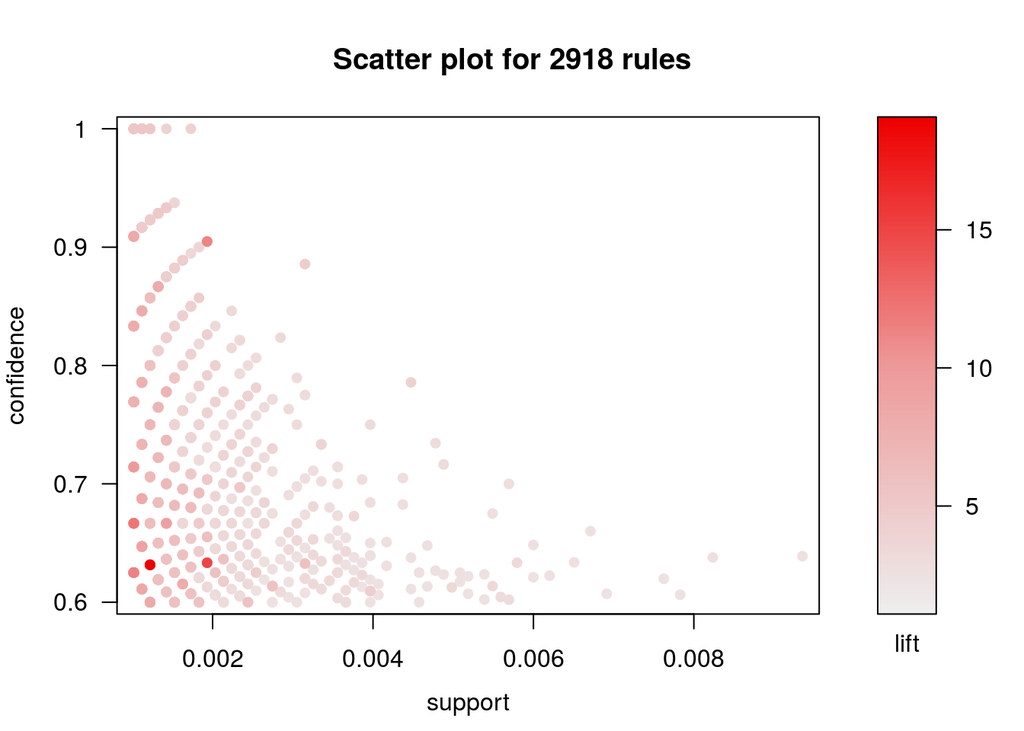

```r
plot(rules)
```

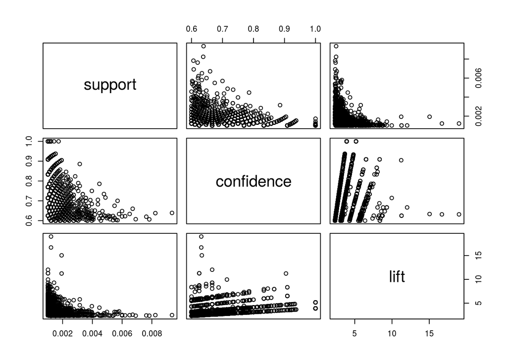

```r
plot(rules@quality)
```

```r
slope <- sort(round(rules@quality$lift / rules@quality$confidence, 2))

# Show how many times a slope shows up in the dataset
table(slope)
```

```
## slope
##  3.91  5.17  5.44  5.73  7.17  9.05  9.17  9.53 10.64 12.08 12.42 13.22
##  1585   940    12     7   188     1   102    55     1     4     1     5
## 13.83 13.95 18.05 23.76 26.44 30.08
##     2     9     3     1     1     1
```

```r
inspect(head(sort(rules, by = "lift"), 10))
```

```
##      lhs                        rhs                      support confidence      lift
## [1]  {Instant food products,
##       soda}                  => {hamburger meat}     0.001220132  0.6315789 18.995654
## [2]  {soda,
##       popcorn}               => {salty snack}        0.001220132  0.6315789 16.697793
## [3]  {ham,
##       processed cheese}      => {white bread}        0.001931876  0.6333333 15.045491
## [4]  {tropical fruit,
##       other vegetables,
##       yogurt,
##       white bread}           => {butter}             0.001016777  0.6666667 12.030581
## [5]  {hamburger meat,
##       yogurt,
##       whipped/sour cream}    => {butter}             0.001016777  0.6250000 11.278670
## [6]  {tropical fruit,
##       other vegetables,
##       whole milk,
##       yogurt,
##       domestic eggs}         => {butter}             0.001016777  0.6250000 11.278670
## [7]  {liquor,
##       red/blush wine}        => {bottled beer}       0.001931876  0.9047619 11.235269
## [8]  {other vegetables,
##       butter,
##       sugar}                 => {whipped/sour cream} 0.001016777  0.7142857  9.964539
## [9]  {whole milk,
##       butter,
##       hard cheese}           => {whipped/sour cream} 0.001423488  0.6666667  9.300236
## [10] {tropical fruit,
##       other vegetables,
##       butter,
##       fruit/vegetable juice} => {whipped/sour cream} 0.001016777  0.6666667  9.300236
```

```r
# The following code fetches a total of 127 rules whose confidence is above 0.9.

confidentRules <- rules[quality(rules)$confidence > 0.9]
confidentRules
```

```
## set of 127 rules
```

[output not shown]

[output cut: 113 more lines]

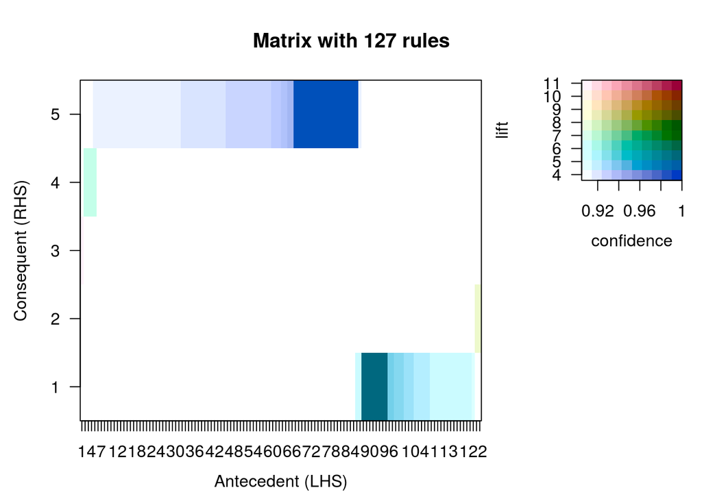

```r
plot(confidentRules, method="matrix", measure = c("lift", "confidence"), control = list(reorder=TRUE))
```

The following code provides a visualization of the top five fules with the highest lift.

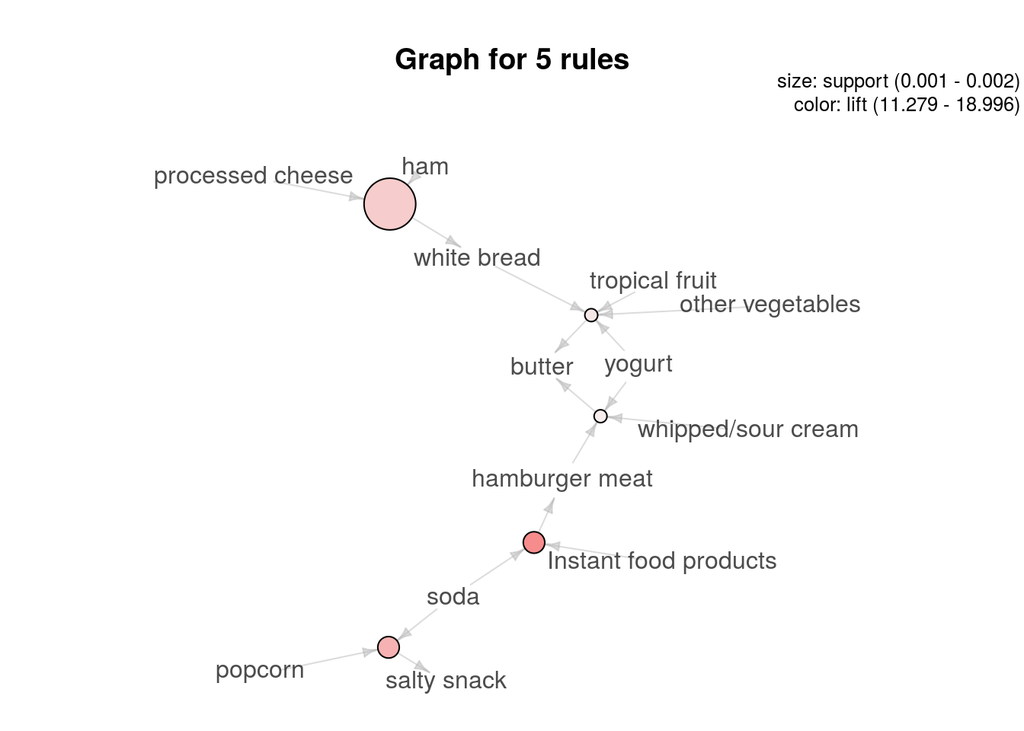

```r
set.seed(2)
highLiftRules <- head(sort(rules, by="lift"), 5)
plot(highLiftRules, method="graph", control = list(type="items"))
```

Support algorithm for 1-itemsets only.

```r
apriorifdRen <- function(data, namesList, minSupport) {

     nTransactions <- ncol(data)
     # sup is shorthand for support
     sup <- nTransactions*minSupport

     # Count how many times each item occurs in the dataset
     itemVec <- vector()
     for(col in 1:ncol(data)) {
          itemVec <- append(itemVec, which(data[,col]))
     }

     itemVec <- table(itemVec)
     itemVec <- itemVec[itemVec >= sup]
     names(itemVec) <- Groceries@itemInfo[,1][as.integer(names(itemVec))]
     sort(itemVec, decreasing = TRUE)/nTransactions
}

itemVec <- apriorifdRen(data = Groceries@data,sort(itemVec, decreasing = TRUE)/ncol(Groceries@data), minSupport = .02)
itemVec
```

```
##               whole milk         other vegetables               rolls/buns
##               0.25551601               0.19349263               0.18393493
##                     soda                   yogurt            bottled water
##               0.17437722               0.13950178               0.11052364
##          root vegetables           tropical fruit            shopping bags
##               0.10899847               0.10493137               0.09852567
##                  sausage                   pastry             citrus fruit
##               0.09395018               0.08896797               0.08276563
##             bottled beer               newspapers              canned beer
##               0.08052872               0.07981698               0.07768175
##                pip fruit    fruit/vegetable juice       whipped/sour cream
##               0.07564820               0.07229283               0.07168277
##              brown bread            domestic eggs              frankfurter
##               0.06487036               0.06344687               0.05897306
##                margarine                   coffee                     pork
##               0.05856634               0.05805796               0.05765125
##                   butter                     curd                     beef
##               0.05541434               0.05327911               0.05246568
##                  napkins                chocolate        frozen vegetables
##               0.05236401               0.04961871               0.04809354
##                  chicken              white bread            cream cheese
##               0.04290798               0.04209456               0.03965430
##                  waffles              salty snack long life bakery product
##               0.03843416               0.03782410               0.03741739
##                  dessert                    sugar                 UHT-milk
##               0.03711235               0.03385867               0.03345196
##           hamburger meat                  berries         hygiene articles
##               0.03324860               0.03324860               0.03294357
##                   onions      specialty chocolate                    candy
##               0.03101169               0.03040163               0.02989324
##             frozen meals          misc. beverages                      oil
##               0.02836807               0.02836807               0.02806304
##              butter milk            specialty bar                      ham
##               0.02796136               0.02735130               0.02602949
##                beverages                     meat                ice cream
##               0.02602949               0.02582613               0.02501271
##            sliced cheese              hard cheese                 cat food
##               0.02450432               0.02450432               0.02328419
##                   grapes              chewing gum
##               0.02236909               0.02104728
```